# Pulse of the Nation Multiple Logistic Regression

```r
POTN<-read.csv("../Data/POTN201801.csv", header=TRUE, stringsAsFactors = FALSE)
POTN<-POTN[c("Age","Female","MT")]
```

### Overview

[Pulse of the Nation](https://thepulseofthenation.com/#intro) is a government funded monthly public opinion poll. It is conducted by the organization Fifth Day of Cards Against Humanity Saves America. To conduct their polls in a scientifically rigorous manner, they partnered with Survey Sampling International — a professional research firm — to contact a nationally representative sample of the American public. They interrupted people’s dinners on both their cell phones and landlines to examine the data for statistically significant correlations.

The [Dataset](https://thepulseofthenation.com/downloads/201801-CAH_PulseOfTheNation_Raw.csv) I will use is a subset of the results of the [survey for January 2018](https://thepulseofthenation.com/#poll-5).

### Dataset

For this analysis, I will explore this question:

**Can a person’s age and gender predict how they feel about women’s ability to multi-task?**

**AGE:** Respondent’s Age

**MT:** Do you believe that women are better at multi-tasking than men?

0. No
1. Yes

**Female:** Respondent’s Gender

0. Male
1. Female

Here is the data I will be using:

```r
datatable(POTN, extensions = "Responsive",options=list(lengthMenu = c(10,25,68)))
```

|  | Age | Female | MT |
| --- | --- | --- | --- |
| 1 | 57 | 1 | 1 |
| 2 | 74 | 1 | 1 |
| 3 | 55 | 0 | 1 |
| 4 | 77 | 1 | 1 |
| 5 | 68 | 0 | 0 |
| 6 | 60 | 1 | 1 |
| 7 | 73 | 0 | 1 |
| 8 | 71 | 1 | 1 |
| 9 | 75 | 1 | 1 |
| 10 | 70 | 1 | 1 |

[output cut: 729 more lines]

### Logistic Regression

To model the probability that someone thinks that females are better at multi-tasking given their age, we could apply the logistic regression model:
$$P(Y_i = 1|x_i) = \frac{e^{\beta_0+\beta_1{X_{i1}}+\beta_2{X_{i2}}+\beta_3{X_{i1}X_{i2}}}}{1+e^{\beta_0+\beta_1{X_{i1}}+\beta_2{X_{i2}}+\beta_3{X_{i1}X_{i2}}}} = \pi_i$$
$\quad Y_{i} = \left\{\begin{array}{ll} 1, & \text{if Feelings} = \text{Yes} \\ 0, & \text{if Feelings} = \text{No} \end{array}\right.$ $\quad X_{i1} = \text{Age}$ $\quad X_{i2} = \left\{\begin{array}{ll} 1, & \text{if Gender} = \text{Female} \\ 0, & \text{if Gender} = \text{Male} \end{array}\right.$

```r
POTN.glm <- glm(MT ~ Age + Female + Age:Female, data=POTN, family=binomial)
pander(summary(POTN.glm))
```

|  | Estimate | Std. Error | z value | Pr(>\|z\|) |
| --- | --- | --- | --- | --- |
| **(Intercept)** | -1.455 | 0.4161 | -3.496 | 0.0004722 |
| **Age** | 0.01955 | 0.007145 | 2.736 | 0.006218 |
| **Female** | 1.831 | 0.5516 | 3.319 | 0.0009028 |
| **Age:Female** | -0.006094 | 0.009465 | -0.6438 | 0.5197 |

(Dispersion parameter for binomial family taken to be 1 )

| Null deviance: | 981.7 on 738 degrees of freedom |
| --- | --- |
| Residual deviance: | 877.2 on 735 degrees of freedom |

```r
b<-POTN.glm$coefficients
pvLR<-coef(summary(POTN.glm))[2,4]
```

$$H_0: \beta_3 = 0 \\
H_a: \beta_3 \neq 0$$

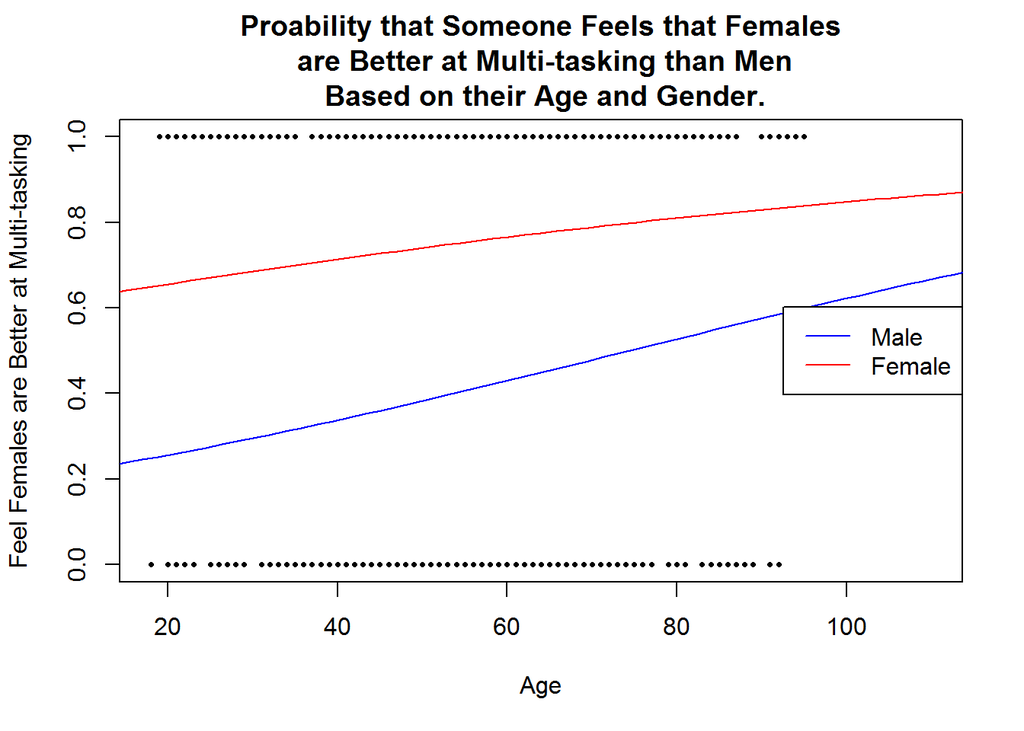

```r
plot(MT ~ Age, data=POTN, pch=16, cex=0.5, xlim=c(18,110), xlab= "Age", ylab="Feel Females are Better at Multi-tasking", main = "Proability that Someone Feels that Females\n are Better at Multi-tasking than Men\n Based on their Age and Gender.")

curve(exp(b[1] + b[2]*x)/(1+exp(b[1] + b[2]*x)),from=0, to=188,  add=TRUE, col='Blue')

curve(exp(b[1]+b[3] + (b[2]+b[4])*x)/(1+exp(b[1]+b[3] + (b[2]+b[4])*x)),from=0, to=188,  add=TRUE, col='red')

legend("right", legend=c("Male", "Female"), col=c("Blue","red"), lty=1)
```

### Appropriateness

Is Logistical Regression an appropriate model for taking age to predict how people feel about female multi-tasking abilities?

I want to test two things:

1. Does the model show that there is a Significant relationship between age and feelings?
2. Is Logistic Regression a Good Fit?

##### Significant

From the Logistic Regression, a p-value of **0.006218** on slope shows that there is a signifcant relationship between age and feelings.

##### Goodness of Fit

We have two goodness of fit tests:

1. Hosmer and Lemeshow goodness of fit (GOF) test for data that has very few repeated x values.
2. Chi-Square Goodness of Fit Test of Deviance for data that has many repeated x values.

Both tests use the same null and alternative hypotheses:

$$H_0:\text{Logistical Model is Appropriate}\\H_a:\text{Logistical Model is Not Appropriate}$$

For the data in this analysis, there are many repeated age values, so the Chi-Square Goodness of Fit Test of Deviance is the more appropriate test.

```r
#pander(table(POTN$MT, POTN$Age), caption = "Age and feelings about female multi-tasking")
```

I will do both tests anyway.

#### Hosmer and Lemeshow Goodness of Fit (GOF) Test

```r
pander(hoslem.test(POTN.glm$y, POTN.glm$fitted))
```

Hosmer and Lemeshow goodness of fit (GOF) test: `POTN.glm$y, POTN.glm$fitted`

| Test statistic | df | P value |
| --- | --- | --- |
| 6.096 | 8 | 0.6365 |

```r
hlpv<-hoslem.test(POTN.glm$y, POTN.glm$fitted)$p.value
```

I will use the Hosmer-Lemeshow test to test the goodness of fit of this logistic regression model. The null assumes the logistic regression is a good fit. With **p=0.6365134**, there is insufficient evidence to reject the null; so, we will conclude a good logistic fit on these data.

```r
a<-summary(POTN.glm)
dfr<-POTN.glm$df.residual

fit<-POTN.glm$fitted

r<-(POTN$MT-fit)/(sqrt(fit*(1-fit)))
srs<-sum(r^2)

pcs<-pchisq(srs, dfr, lower.tail = FALSE)
```

#### Chi-Square Goodness of Fit Test of Deviance

I will use the Chi-Square Goodness of Fit Test of Deviance to test the goodness of fit of this logistic regression model. The null assumes the logistic regression is a good fit. With **p=0.4485757**, there is insufficient evidence to reject the null; so, we will conclude a good logistic fit on these data.

### Interpretation

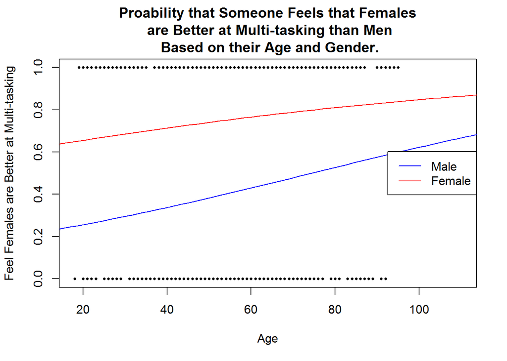

```r
plot(MT ~ Age, data=POTN, pch=16, cex=0.5, xlim=c(18,110), xlab= "Age", ylab="Feel Females are Better at Multi-tasking", main = "Proability that Someone Feels that Females\n are Better at Multi-tasking than Men\n Based on their Age and Gender.")

curve(exp(b[1] + b[2]*x)/(1+exp(b[1] + b[2]*x)),from=0, to=188,  add=TRUE, col='Blue')

curve(exp(b[1]+b[3] + (b[2]+b[4])*x)/(1+exp(b[1]+b[3] + (b[2]+b[4])*x)),from=0, to=188,  add=TRUE, col='red')

legend("right", legend=c("Male", "Female"), col=c("Blue","red"), lty=1)
```

```r
pander(summary(POTN.glm))
```

|  | Estimate | Std. Error | z value | Pr(>\|z\|) |
| --- | --- | --- | --- | --- |
| **(Intercept)** | -1.455 | 0.4161 | -3.496 | 0.0004722 |
| **Age** | 0.01955 | 0.007145 | 2.736 | 0.006218 |
| **Female** | 1.831 | 0.5516 | 3.319 | 0.0009028 |
| **Age:Female** | -0.006094 | 0.009465 | -0.6438 | 0.5197 |

(Dispersion parameter for binomial family taken to be 1 )

| Null deviance: | 981.7 on 738 degrees of freedom |
| --- | --- |
| Residual deviance: | 877.2 on 735 degrees of freedom |

##### Conclusion

It appears that age is an appropriate predictor of whether a person feels that females are better at multi-tasking.

The trouble with the interpretation of $e^{b_0}$ and $e^{b_0 + b_2}$ is that it represents the feelings of newborns about females’ ability to multi-task. I think their opinions are biased.